# Looking at covariates

Supp figure for the MiGA paper

Katia de Paiva Lopes Raj Lab Department of Neuroscience Icahn School of Medicine at Mount Sinai NYC, New York

2020-10-20

> 255 samples (from 314) | Different brain regions from the same donor | Multi disease cohort.

```r
work_dir = "~/pd-omics/katia/Microglia/mic_255s/"
expression_dir = "~/ad-omics_hydra/microglia_omics/expression_tables/added_pilot_314s/expr_4brain_regions/"
metadata_path = "~/pd-omics/katia/Microglia/mic_255s/metadata_files/"
```

## Input

This metadata contains biological and technical covariates.

```r
load(paste0(expression_dir, "Expression_filt_255s.Rdata"))
# dim(genes_counts_exp_3rd) # 19376   255

load(paste0(metadata_path, "metadata_255filt_eng_29jun2020.Rdata"))
# str(metadata3rd_pass)

metadata <- metadata3rd_pass

metadata$cause_of_death_categories[metadata$cause_of_death_categories %in% NA] <- "Other"
#table(metadata$cause_of_death_categories)
metadata$C1 = metadata$C1 %>% replace_na(median(metadata$C1, na.rm = T))
metadata$C2 = metadata$C2 %>% replace_na(median(metadata$C2, na.rm = T))
metadata$C3 = metadata$C3 %>% replace_na(median(metadata$C3, na.rm = T))
metadata$C4 = metadata$C4 %>% replace_na(median(metadata$C4, na.rm = T))
```

## HMs: PCA x covariates

```r
genes_counts_voom <- genes_counts_voom_3rd
#pca_voom = prcomp(t(genes_counts_voom)) #Same PCA from Analysis_clean
pca_voom = prcomp(genes_counts_voom)
# createDT(pca_voom$rotation[1:10, 1:5])
pcva_voom_selec = pca_voom$rotation[, 1:15] #15 firsts PCs
#autoplot(pca_voom)
```

### With p-values

> **Linear regression** between the first 15 PCs and selected covariates. Colors = adj.r.square Numbers = p-values adjusted by Bonferroni.

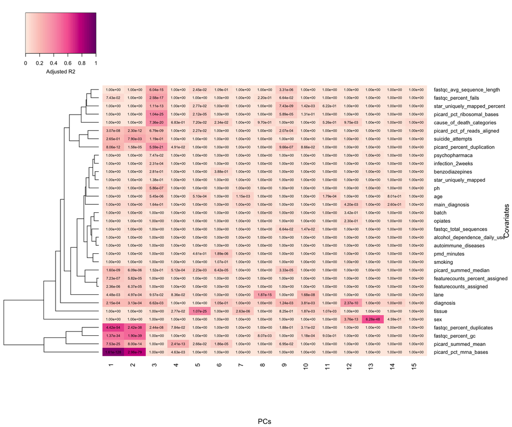

```r
var <- get_pca_var(pca_voom) # description of PCs
ind <- get_pca_ind(pca_voom) # PCs for individuals

# To include our batch
names(metadata) = tolower(names(metadata))
# Transforms characters columns in factors columns
indx <- sapply(metadata, is.character)
metadata[indx] <- lapply(metadata[indx], function(x) as.factor(x))
metadata$ph = as.numeric(as.character(metadata$ph))
#str(metadata) #shows class for all columns

#Covariates
covariates = c( "diagnosis",
                "main_diagnosis",
                "tissue",
                "sex",
                "age",
                "pmd_minutes",
                "ph",
                "cause_of_death_categories",
                "smoking",
                "alcohol_dependence_daily_use",
                "suicide_attempts",
                "autoimmune_diseases",
                "infection_2weeks",
                "opiates",
                "benzodiazepines",
                "psychopharmaca",
                "featurecounts_percent_assigned",
                "featurecounts_assigned",
                "picard_pct_ribosomal_bases",
                "picard_pct_mrna_bases",
                "picard_pct_pf_reads_aligned",
                "picard_summed_median",
                "picard_summed_mean",
                "picard_percent_duplication",
                "star_uniquely_mapped_percent",
                "star_uniquely_mapped",
                "fastqc_percent_duplicates",
                "fastqc_percent_gc",
                "fastqc_avg_sequence_length",
                "fastqc_percent_fails",
                "fastqc_total_sequences",
                "lane",
                "batch")


matrix_rsquared = matrix(NA, nrow = length(covariates), ncol = 15) #Number of factors
matrix_pvalue = matrix(NA, nrow = length(covariates), ncol = 15)

for (x in 1:length(covariates)){
  for (y in 1:15){
    matrix_rsquared[x,y] <- summary( lm(var$cor[,y] ~ metadata[,covariates[x]]) )$adj.r.squared
    matrix_pvalue[x,y] <- glance(summary( lm(var$cor[,y] ~ metadata[,covariates[x]]) ))$p.value #To insert pvalues in the heatmap
  }
}

rownames(matrix_rsquared) = covariates
rownames(matrix_pvalue) = covariates

matrix_pvalue = matrix(p.adjust(as.vector(as.matrix(matrix_pvalue)), method='bonferroni'),ncol=ncol(matrix_pvalue))
matrix_pvalue = formatC(matrix_pvalue, format = "e", digits = 2)

# png(paste0(work_dir, "LinearReg_15pcs_covariates.png"), width = 10, height = 10, res = 600, units = "in")
# pdf(paste0(work_dir, "LinearReg_15pcs_covariates.pdf"), width = 10, height = 10)
heatmap.2(as.matrix(matrix_rsquared), col = colorRampPalette(RColorBrewer::brewer.pal(6,"RdPu"))(40),
          scale="none",
          cellnote = matrix_pvalue,
          notecol="black",
          notecex = 0.6,
          margins=c(10,12), # ("margin.Y", "margin.X")
          trace='none',
          #dendrogram=c("row"),
          density.info='none',
          denscol="black",
          breaks = seq(0, 1, length.out = 41),
          Colv = FALSE,
          xlab = "PCs",
          ylab = "Covariates",
          key = TRUE,
          keysize = 1,
          key.title = "teste",
          key.xlab = "Adjusted R2",
          key.ylab = NULL,
          key.xtickfun = NULL,
          key.ytickfun = NULL,
          key.par=list()
#          main = "Linear regression between PCs and covariates"
)
#while (!is.null(dev.list()))  dev.off()
# dev.off()
# Colored by adj.r.squared
# Numbers inside cell = pvalues
```

### Clean heatmap

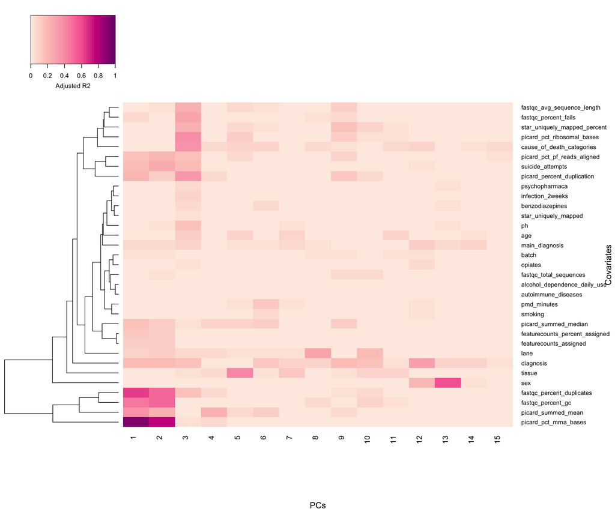

```r
# png(paste0(work_dir, "LinearReg_15pcs_covariates_clean.png"), width = 8, height = 10, res = 600, units = "in")
# pdf(paste0(work_dir, "LinearReg_15pcs_covariates_clean.pdf"), width = 8, height = 10)
heatmap.2(as.matrix(matrix_rsquared), col = colorRampPalette(RColorBrewer::brewer.pal(6,"RdPu"))(40),
          scale="none",
#          cellnote = matrix_pvalue,
          notecol="black",
          notecex = 0.6,
          margins=c(10,12), # ("margin.Y", "margin.X")
          trace='none',
          dendrogram=c("row"),
          density.info='none',
          denscol="black",
          breaks = seq(0, 1, length.out = 41),
          Colv = FALSE,
          xlab = "PCs",
          ylab = "Covariates",
          keysize = 1,
          key.title = "teste",
          key.xlab = "Adjusted R2"
#          main = "Linear regression between sva_network and covariates"
)

# dev.off()
# Colored by adj.r.squared
```

R version 3.6.2 (2019-12-12) Platform: x86_64-apple-darwin15.6.0 (64-bit) Running under: macOS Catalina 10.15.7

Matrix products: default BLAS: /Library/Frameworks/R.framework/Versions/3.6/Resources/lib/libRblas.0.dylib LAPACK: /Library/Frameworks/R.framework/Versions/3.6/Resources/lib/libRlapack.dylib

locale: [1] en_US.UTF-8/en_US.UTF-8/en_US.UTF-8/C/en_US.UTF-8/en_US.UTF-8

attached base packages: [1] stats4 parallel stats graphics grDevices utils datasets [8] methods base

other attached packages: [1] forcats_0.4.0 stringr_1.4.0  
[3] dplyr_1.0.0 purrr_0.3.4  
[5] readr_1.3.1 tidyr_1.1.0  
[7] tibble_3.0.1 tidyverse_1.3.0  
[9] broom_0.5.6 edgeR_3.28.0  
[11] DESeq2_1.26.0 SummarizedExperiment_1.16.1 [13] DelayedArray_0.12.1 BiocParallel_1.20.1  
[15] matrixStats_0.55.0 GenomicRanges_1.38.0  
[17] GenomeInfoDb_1.22.0 IRanges_2.20.1  
[19] S4Vectors_0.24.1 pamr_1.56.1  
[21] survival_3.1-8 cluster_2.1.0  
[23] factoextra_1.0.6 gplots_3.0.3  
[25] ggfortify_0.4.10 variancePartition_1.17.7  
[27] Biobase_2.46.0 BiocGenerics_0.32.0  
[29] scales_1.1.1 foreach_1.4.8  
[31] limma_3.42.0 ggplot2_3.3.2